# Neural Nets

Reference Notebook for Neural Nets. Watch the video lecture for the full breakdown.

## The Data

We will use the popular [Boston dataset](http://www.cs.toronto.edu/~delve/data/boston/bostonDetail.html) from the MASS package, which describes some features for houses in Boston in 1978.

- CRIM - per capita crime rate by town
- ZN - proportion of residential land zoned for lots over 25,000 sq.ft.
- INDUS - proportion of non-retail business acres per town.
- CHAS - Charles River dummy variable (1 if tract bounds river; 0 otherwise)
- NOX - nitric oxides concentration (parts per 10 million)
- RM - average number of rooms per dwelling
- AGE - proportion of owner-occupied units built prior to 1940
- DIS - weighted distances to five Boston employment centres
- RAD - index of accessibility to radial highways
- TAX - full-value property-tax rate per 10,000 dollars
- PTRATIO - pupil-teacher ratio by town
- B - 1000(Bk - 0.63)^2 where Bk is the proportion of blacks by town
- LSTAT - % lower status of the population
- MEDV - Median value of owner-occupied homes in $1000's

We will be trying to predict the Median Value MEDV

```r
library(MASS)
```

```r
set.seed(101)
data <- Boston
```

```r
str(data)
```

```
'data.frame':	506 obs. of  14 variables:
 $ crim   : num  0.00632 0.02731 0.02729 0.03237 0.06905 ...
 $ zn     : num  18 0 0 0 0 0 12.5 12.5 12.5 12.5 ...
 $ indus  : num  2.31 7.07 7.07 2.18 2.18 2.18 7.87 7.87 7.87 7.87 ...
 $ chas   : int  0 0 0 0 0 0 0 0 0 0 ...
 $ nox    : num  0.538 0.469 0.469 0.458 0.458 0.458 0.524 0.524 0.524 0.524 ...
 $ rm     : num  6.58 6.42 7.18 7 7.15 ...
 $ age    : num  65.2 78.9 61.1 45.8 54.2 58.7 66.6 96.1 100 85.9 ...
 $ dis    : num  4.09 4.97 4.97 6.06 6.06 ...
 $ rad    : int  1 2 2 3 3 3 5 5 5 5 ...
 $ tax    : num  296 242 242 222 222 222 311 311 311 311 ...
 $ ptratio: num  15.3 17.8 17.8 18.7 18.7 18.7 15.2 15.2 15.2 15.2 ...
 $ black  : num  397 397 393 395 397 ...
 $ lstat  : num  4.98 9.14 4.03 2.94 5.33 ...
 $ medv   : num  24 21.6 34.7 33.4 36.2 28.7 22.9 27.1 16.5 18.9 ...
```

```r
summary(data)
```

```
      crim                zn             indus            chas
 Min.   : 0.00632   Min.   :  0.00   Min.   : 0.46   Min.   :0.00000
 1st Qu.: 0.08204   1st Qu.:  0.00   1st Qu.: 5.19   1st Qu.:0.00000
 Median : 0.25651   Median :  0.00   Median : 9.69   Median :0.00000
 Mean   : 3.61352   Mean   : 11.36   Mean   :11.14   Mean   :0.06917
 3rd Qu.: 3.67708   3rd Qu.: 12.50   3rd Qu.:18.10   3rd Qu.:0.00000
 Max.   :88.97620   Max.   :100.00   Max.   :27.74   Max.   :1.00000
      nox               rm             age              dis
 Min.   :0.3850   Min.   :3.561   Min.   :  2.90   Min.   : 1.130
 1st Qu.:0.4490   1st Qu.:5.886   1st Qu.: 45.02   1st Qu.: 2.100
 Median :0.5380   Median :6.208   Median : 77.50   Median : 3.207
 Mean   :0.5547   Mean   :6.285   Mean   : 68.57   Mean   : 3.795
 3rd Qu.:0.6240   3rd Qu.:6.623   3rd Qu.: 94.08   3rd Qu.: 5.188
 Max.   :0.8710   Max.   :8.780   Max.   :100.00   Max.   :12.127
      rad              tax           ptratio          black
 Min.   : 1.000   Min.   :187.0   Min.   :12.60   Min.   :  0.32
 1st Qu.: 4.000   1st Qu.:279.0   1st Qu.:17.40   1st Qu.:375.38
 Median : 5.000   Median :330.0   Median :19.05   Median :391.44
 Mean   : 9.549   Mean   :408.2   Mean   :18.46   Mean   :356.67
 3rd Qu.:24.000   3rd Qu.:666.0   3rd Qu.:20.20   3rd Qu.:396.23
 Max.   :24.000   Max.   :711.0   Max.   :22.00   Max.   :396.90
     lstat            medv
 Min.   : 1.73   Min.   : 5.00
 1st Qu.: 6.95   1st Qu.:17.02
 Median :11.36   Median :21.20
 Mean   :12.65   Mean   :22.53
 3rd Qu.:16.95   3rd Qu.:25.00
 Max.   :37.97   Max.   :50.00
```

```r
head(data)
```

|  | crim | zn | indus | chas | nox | rm | age | dis | rad | tax | ptratio | black | lstat | medv |
| --- | --- | --- | --- | --- | --- | --- | --- | --- | --- | --- | --- | --- | --- | --- |
| 1 | 0.00632 | 18 | 2.31 | 0 | 0.538 | 6.575 | 65.2 | 4.09 | 1 | 296 | 15.3 | 396.9 | 4.98 | 24 |
| 2 | 0.02731 | 0 | 7.07 | 0 | 0.469 | 6.421 | 78.9 | 4.9671 | 2 | 242 | 17.8 | 396.9 | 9.14 | 21.6 |
| 3 | 0.02729 | 0 | 7.07 | 0 | 0.469 | 7.185 | 61.1 | 4.9671 | 2 | 242 | 17.8 | 392.83 | 4.03 | 34.7 |
| 4 | 0.03237 | 0 | 2.18 | 0 | 0.458 | 6.998 | 45.8 | 6.0622 | 3 | 222 | 18.7 | 394.63 | 2.94 | 33.4 |
| 5 | 0.06905 | 0 | 2.18 | 0 | 0.458 | 7.147 | 54.2 | 6.0622 | 3 | 222 | 18.7 | 396.9 | 5.33 | 36.2 |
| 6 | 0.02985 | 0 | 2.18 | 0 | 0.458 | 6.43 | 58.7 | 6.0622 | 3 | 222 | 18.7 | 394.12 | 5.21 | 28.7 |

```r
any(is.na(data))
```

FALSE

## Neural Net Model

First you'll need to install the neural net library:

```r
#install.packages('neuralnet',repos = 'http://cran.us.r-project.org')
```

```r
library(neuralnet)
```

## Training the Model

As a first step, we are going to address data preprocessing. It is good practice to normalize your data before training a neural network. Depending on your dataset, avoiding normalization may lead to useless results or to a very difficult training process (most of the times the algorithm will not converge before the number of maximum iterations allowed). You can choose different methods to scale the data (z-normalization, min-max scale, etc…). Usually scaling in the intervals [0,1] or [-1,1] tends to give better results. We therefore scale and split the data before moving on:

```r
maxs <- apply(data, 2, max)
mins <- apply(data, 2, min)
```

```r
maxs
```

**crim**

88.9762

**zn**

100

**indus**

27.74

**chas**

1

**nox**

0.871

**rm**

8.78

**age**

100

**dis**

12.1265

**rad**

24

**tax**

711

**ptratio**

22

**black**

396.9

**lstat**

37.97

**medv**

50

```r
mins
```

**crim**

0.00632

**zn**

0

**indus**

0.46

**chas**

0

**nox**

0.385

**rm**

3.561

**age**

2.9

**dis**

1.1296

**rad**

1

**tax**

187

**ptratio**

12.6

**black**

0.32

**lstat**

1.73

**medv**

5

```r
scaled <- as.data.frame(scale(data, center = mins, scale = maxs - mins))
```

```r
head(scaled)
```

|  | crim | zn | indus | chas | nox | rm | age | dis | rad | tax | ptratio | black | lstat | medv |
| --- | --- | --- | --- | --- | --- | --- | --- | --- | --- | --- | --- | --- | --- | --- |
| 1 | 0 | 0.18 | 0.06781525 | 0 | 0.3148148 | 0.5775053 | 0.6416066 | 0.2692031 | 0 | 0.2080153 | 0.287234 | 1 | 0.08967991 | 0.4222222 |
| 2 | 0.0002359225 | 0 | 0.2423021 | 0 | 0.1728395 | 0.5479977 | 0.7826982 | 0.348962 | 0.04347826 | 0.1049618 | 0.5531915 | 1 | 0.2044702 | 0.3688889 |
| 3 | 0.0002356977 | 0 | 0.2423021 | 0 | 0.1728395 | 0.6943859 | 0.5993821 | 0.348962 | 0.04347826 | 0.1049618 | 0.5531915 | 0.9897373 | 0.06346578 | 0.66 |
| 4 | 0.0002927957 | 0 | 0.06304985 | 0 | 0.1502058 | 0.6585553 | 0.4418126 | 0.4485446 | 0.08695652 | 0.06679389 | 0.6489362 | 0.9942761 | 0.03338852 | 0.6311111 |
| 5 | 0.0007050701 | 0 | 0.06304985 | 0 | 0.1502058 | 0.6871048 | 0.5283213 | 0.4485446 | 0.08695652 | 0.06679389 | 0.6489362 | 1 | 0.09933775 | 0.6933333 |
| 6 | 0.0002644715 | 0 | 0.06304985 | 0 | 0.1502058 | 0.5497222 | 0.5746653 | 0.4485446 | 0.08695652 | 0.06679389 | 0.6489362 | 0.9929901 | 0.09602649 | 0.5266667 |

## Train and Test Sets

Now with our standardized data, let's split it:

```r
library(caTools)
split = sample.split(scaled$medv, SplitRatio = 0.70)

train = subset(scaled, split == TRUE)
test = subset(scaled, split == FALSE)
```

## Training the Model

```r
# Call package
library(neuralnet)
```

#### Formula for Neural Net

For some odd reasons, the neuralnet() function won't accept a formula in the form: y~. that we are used to using. Instead you have to call all the columns added together. Here is some convience code to help quickly create that formula:

```r
# Get column names
n <- names(train)
```

```r
n
```

1. 'crim'

2. 'zn'

3. 'indus'

4. 'chas'

5. 'nox'

6. 'rm'

7. 'age'

8. 'dis'

9. 'rad'

10. 'tax'

11. 'ptratio'

12. 'black'

13. 'lstat'

14. 'medv'

```r
# Paste together
f <- as.formula(paste("medv ~", paste(n[!n %in% "medv"], collapse = " + ")))
```

```r
f
```

```
medv ~ crim + zn + indus + chas + nox + rm + age + dis + rad +
    tax + ptratio + black + lstat
```

```r
nn <- neuralnet(f,data=train,hidden=c(5,3),linear.output=TRUE)
```

```r
#plot(nn)
```

## Predictions using the Model

Now we can try to predict the values for the test set and calculate the MSE. Remember that the net will output a normalized prediction, so we need to scale it back in order to make a meaningful comparison (or just a simple prediction).

```r
# Compute Predictions off Test Set
predicted.nn.values <- compute(nn,test[1:13])
```

```r
# Its a list returned
str(predicted.nn.values)
```

```
List of 2
 $ neurons   :List of 3
  ..$ : num [1:139, 1:14] 1 1 1 1 1 1 1 1 1 1 ...
  .. ..- attr(*, "dimnames")=List of 2
  .. .. ..$ : chr [1:139] "4" "6" "8" "9" ...
  .. .. ..$ : chr [1:14] "1" "crim" "zn" "indus" ...
  ..$ : num [1:139, 1:6] 1 1 1 1 1 1 1 1 1 1 ...
  .. ..- attr(*, "dimnames")=List of 2
  .. .. ..$ : chr [1:139] "4" "6" "8" "9" ...
  .. .. ..$ : NULL
  ..$ : num [1:139, 1:4] 1 1 1 1 1 1 1 1 1 1 ...
  .. ..- attr(*, "dimnames")=List of 2
  .. .. ..$ : chr [1:139] "4" "6" "8" "9" ...
  .. .. ..$ : NULL
 $ net.result: num [1:139, 1] 0.552 0.422 0.342 0.252 0.365 ...
  ..- attr(*, "dimnames")=List of 2
  .. ..$ : chr [1:139] "4" "6" "8" "9" ...
  .. ..$ : NULL
```

```r
# Convert back to non-scaled predictions
true.predictions <- predicted.nn.values$net.result*(max(data$medv)-min(data$medv))+min(data$medv)
```

```r
# Convert the test data
test.r <- (test$medv)*(max(data$medv)-min(data$medv))+min(data$medv)
```

```r
# Check the Mean Squared Error
MSE.nn <- sum((test.r - true.predictions)^2)/nrow(test)
```

```r
MSE.nn
```

```
[1] 20.45308118
```

## Visualize Error

```r
error.df <- data.frame(test.r,true.predictions)
```

```r
head(error.df)
```

|  | test.r | true.predictions |
| --- | --- | --- |
| 4 | 33.4 | 29.8568621 |
| 6 | 28.7 | 23.99832638 |
| 8 | 27.1 | 20.37098111 |
| 9 | 16.5 | 16.32652695 |
| 11 | 15 | 21.412632 |
| 14 | 20.4 | 18.71094098 |

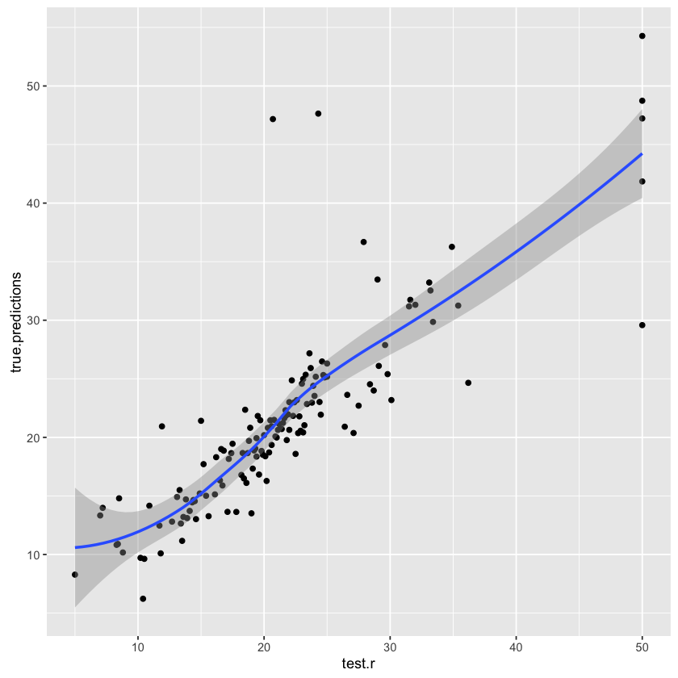

```r
library(ggplot2)
ggplot(error.df,aes(x=test.r,y=true.predictions)) + geom_point() + stat_smooth()
```

Looks like a few houses threw off our model, but overall its not looking too bad considering we're pretty much treating it like a total black box.

## Conclusion

Neural networks resemble black boxes a lot: explaining their outcome is much more difficult than explaining the outcome of simpler model such as a linear model. Therefore, depending on the kind of application you need, you might want to take into account this factor too. Furthermore, as you have seen above, extra care is needed to fit a neural network and small changes can lead to different results.